# 03_optimization

## 講義「機械学習」2回目

### 勾配法によるパラメータの最適化

このファイルはレポート課題としてAIMSで提出してください。

学籍番号： 1193033130

氏名： 藤井絢斗

```python
import numpy as np
import matplotlib.pyplot as plt
```

### 例題3-1：

勾配法を実行する関数optimizationを作成せよ。  
ただし、引数と戻り値は以下の通りとする。

[引数]  
f: 目的関数  
df: 目的関数の1次導関数  
x0: 初期点  
alpha: 学習率  
max_itr: 更新回数

[戻り値]  
x_seq: 最適化の過程を記録した変数xの点列

```python
import pandas as pd
import numpy as np

def optimization(f, df, x0, alpha, max_itr):
    x_seq = [x0]
    for i in range(max_itr):
        x_seq.append(x_seq[i] - alpha * df(x_seq[i]))
    return x_seq
```

### 例題3-2

上記で定義した関数optimizationを用いて、 目的関数$f(x)=(x-1)**2$を勾配法で最適化せよ。

目的関数の定義

```python
def f(x):
    return (x-1)**2
```

導関数の定義

```python
def df(x):
    return 2*(x-1)
```

初期点4, 学習率0.01, 更新回数20で最適化を実行して、学習過程を描画せよ。  
また、更新後のxの値、目的関数の値を出力せよ。

```
xの値:4.000,  関数の値:9.000
xの値:3.940,  関数の値:8.644
xの値:3.881,  関数の値:8.301
xの値:3.824,  関数の値:7.973
xの値:3.767,  関数の値:7.657
xの値:3.712,  関数の値:7.354
xの値:3.658,  関数の値:7.062
xの値:3.604,  関数の値:6.783
xの値:3.552,  関数の値:6.514
xの値:3.501,  関数の値:6.256
xの値:3.451,  関数の値:6.008
xの値:3.402,  関数の値:5.771
xの値:3.354,  関数の値:5.542
xの値:3.307,  関数の値:5.323
xの値:3.261,  関数の値:5.112
xの値:3.216,  関数の値:4.909
xの値:3.171,  関数の値:4.715
xの値:3.128,  関数の値:4.528
xの値:3.085,  関数の値:4.349
xの値:3.044,  関数の値:4.177
xの値:3.003,  関数の値:4.011
```

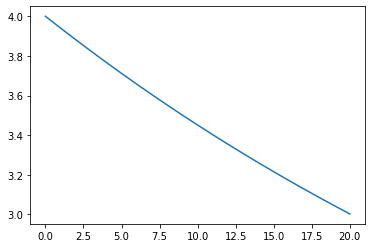

```python
def x_print(opt):
    plt.plot(opt)
    for i in range(len(opt)):
        print(f"xの値:{opt[i]:.3f},  関数の値:{f(opt[i]):.3f}")
        continue

opt11 = optimization(f, df, 4, 0.01, 20)
x_print(opt11)
```

初期点4, 学習率0.1, 更新回数20で最適化を実行して、学習過程を描画せよ。  
また、更新後のxの値、目的関数の値を出力せよ。

```
xの値:4.000,  関数の値:9.000
xの値:3.400,  関数の値:5.760
xの値:2.920,  関数の値:3.686
xの値:2.536,  関数の値:2.359
xの値:2.229,  関数の値:1.510
xの値:1.983,  関数の値:0.966
xの値:1.786,  関数の値:0.618
xの値:1.629,  関数の値:0.396
xの値:1.503,  関数の値:0.253
xの値:1.403,  関数の値:0.162
xの値:1.322,  関数の値:0.104
xの値:1.258,  関数の値:0.066
xの値:1.206,  関数の値:0.043
xの値:1.165,  関数の値:0.027
xの値:1.132,  関数の値:0.017
xの値:1.106,  関数の値:0.011
xの値:1.084,  関数の値:0.007
xの値:1.068,  関数の値:0.005
xの値:1.054,  関数の値:0.003
xの値:1.043,  関数の値:0.002
xの値:1.035,  関数の値:0.001
```

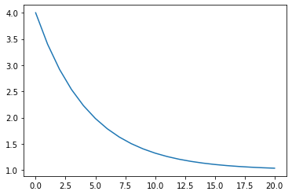

```python
opt12 = optimization(f, df, 4, 0.1, 20)
x_print(opt12)
```

初期点-3, 学習率0.1, 更新回数20で最適化を実行して、学習過程を描画せよ。  
また、更新後のxの値、目的関数の値を出力せよ。

```
xの値:-3.000,  関数の値:16.000
xの値:-2.200,  関数の値:10.240
xの値:-1.560,  関数の値:6.554
xの値:-1.048,  関数の値:4.194
xの値:-0.638,  関数の値:2.684
xの値:-0.311,  関数の値:1.718
xの値:-0.049,  関数の値:1.100
xの値:0.161,  関数の値:0.704
xの値:0.329,  関数の値:0.450
xの値:0.463,  関数の値:0.288
xの値:0.571,  関数の値:0.184
xの値:0.656,  関数の値:0.118
xの値:0.725,  関数の値:0.076
xの値:0.780,  関数の値:0.048
xの値:0.824,  関数の値:0.031
xの値:0.859,  関数の値:0.020
xの値:0.887,  関数の値:0.013
xの値:0.910,  関数の値:0.008
xの値:0.928,  関数の値:0.005
xの値:0.942,  関数の値:0.003
xの値:0.954,  関数の値:0.002
```

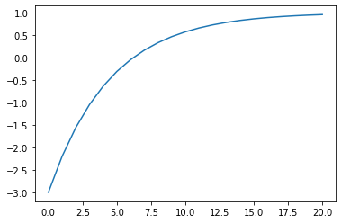

```python
opt13 = optimization(f, df, -3, 0.1, 20)
x_print(opt13)
```

初期点4, 学習率0.75, 更新回数20で最適化を実行して、学習過程を描画せよ。  
また、更新後のxの値、目的関数の値を出力せよ。

```
xの値:4.000,  関数の値:9.000
xの値:-0.500,  関数の値:2.250
xの値:1.750,  関数の値:0.562
xの値:0.625,  関数の値:0.141
xの値:1.188,  関数の値:0.035
xの値:0.906,  関数の値:0.009
xの値:1.047,  関数の値:0.002
xの値:0.977,  関数の値:0.001
xの値:1.012,  関数の値:0.000
xの値:0.994,  関数の値:0.000
xの値:1.003,  関数の値:0.000
xの値:0.999,  関数の値:0.000
xの値:1.001,  関数の値:0.000
xの値:1.000,  関数の値:0.000
xの値:1.000,  関数の値:0.000
xの値:1.000,  関数の値:0.000
xの値:1.000,  関数の値:0.000
xの値:1.000,  関数の値:0.000
xの値:1.000,  関数の値:0.000
xの値:1.000,  関数の値:0.000
xの値:1.000,  関数の値:0.000
```

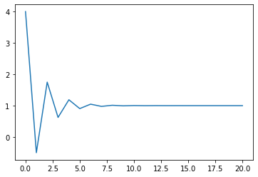

```python
opt14 = optimization(f, df, 4, 0.75, 20)
x_print(opt14)
```

### 例題２

目的関数 $f(x)=(x-2.5)(x-2)(x+1)x$ を勾配法で最適化せよ

目的関数の定義

```python
def f2(x):
    return (x-2.5)*(x-2)*(x+1)*x
```

導関数の定義

```python
def df2(x):
    #return ( (x-2)*(x+1)*x + (x-2.5)*(x+1)*(x) + (x-2.5)*(x-2)*(x) + (x-2.5)*(x-2)*(x+1) )
    return 4*(x**3) - 10.5*x**2 + x + 5
```

初期点3, 学習率0.01, 更新回数20で最適化を実行して、学習過程を描画せよ。  
また、更新後のxの値、目的関数の値を出力せよ。

```
xの値:3.000,  関数の値:6.000
xの値:2.785,  関数の値:2.358
xの値:2.658,  関数の値:1.007
xの値:2.572,  関数の値:0.377
xの値:2.510,  関数の値:0.045
xの値:2.464,  関数の値:-0.143
xの値:2.428,  関数の値:-0.255
xの値:2.401,  関数の値:-0.325
xの値:2.378,  関数の値:-0.370
xの値:2.360,  関数の値:-0.399
xの値:2.346,  関数の値:-0.419
xの値:2.334,  関数の値:-0.432
xの値:2.324,  関数の値:-0.441
xの値:2.316,  関数の値:-0.447
xの値:2.309,  関数の値:-0.451
xの値:2.303,  関数の値:-0.454
xの値:2.298,  関数の値:-0.456
xの値:2.294,  関数の値:-0.458
xの値:2.291,  関数の値:-0.459
xの値:2.288,  関数の値:-0.459
xの値:2.286,  関数の値:-0.460
```

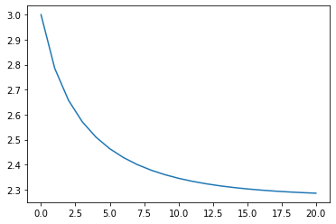

```python
def x2_print(opt):
    plt.plot(opt)
    for i in range(len(opt)):
        print(f"xの値:{opt[i]:.3f},  関数の値:{f2(opt[i]):.3f}")
        continue

opt21 = optimization(f2, df2, 3, 0.01, 20)
x2_print(opt21)
```

初期点1, 学習率0.1, 更新回数20で最適化を実行して、学習過程を描画せよ。  
また、更新後のxの値、目的関数の値を出力せよ。

```
xの値:1.000,  関数の値:3.000
xの値:1.050,  関数の値:2.965
xの値:1.140,  関数の値:2.854
xの値:1.297,  関数の値:2.519
xの値:1.561,  関数の値:1.647
xの値:1.942,  関数の値:0.184
xの値:2.278,  関数の値:-0.461
xの値:2.270,  関数の値:-0.461
xの値:2.275,  関数の値:-0.461
xの値:2.272,  関数の値:-0.461
xの値:2.273,  関数の値:-0.461
xの値:2.273,  関数の値:-0.461
xの値:2.273,  関数の値:-0.461
xの値:2.273,  関数の値:-0.461
xの値:2.273,  関数の値:-0.461
xの値:2.273,  関数の値:-0.461
xの値:2.273,  関数の値:-0.461
xの値:2.273,  関数の値:-0.461
xの値:2.273,  関数の値:-0.461
xの値:2.273,  関数の値:-0.461
xの値:2.273,  関数の値:-0.461
```

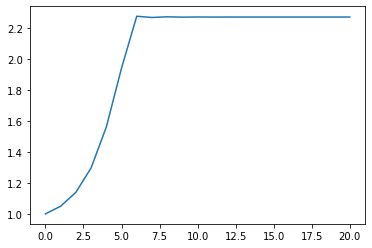

```python
opt22 = optimization(f2, df2, 1, 0.1, 20)
x2_print(opt22)
```

初期点0.7, 学習率0.1, 更新回数20で最適化を実行して、学習過程を描画せよ。  
また、更新後のxの値、目的関数の値を出力せよ。

```
xの値:0.700,  関数の値:2.785
xの値:0.507,  関数の値:2.274
xの値:0.175,  関数の値:0.870
xの値:-0.313,  関数の値:-1.399
xの値:-0.667,  関数の値:-1.877
xの値:-0.515,  関数の値:-1.894
xの値:-0.630,  関数の値:-1.919
xの値:-0.550,  関数の値:-1.925
xの値:-0.611,  関数の値:-1.931
xの値:-0.567,  関数の値:-1.933
xの値:-0.600,  関数の値:-1.934
xの値:-0.576,  関数の値:-1.935
xの値:-0.594,  関数の値:-1.936
xの値:-0.580,  関数の値:-1.936
xの値:-0.590,  関数の値:-1.936
xの値:-0.583,  関数の値:-1.936
xの値:-0.589,  関数の値:-1.936
xの値:-0.584,  関数の値:-1.936
xの値:-0.588,  関数の値:-1.936
xの値:-0.585,  関数の値:-1.936
xの値:-0.587,  関数の値:-1.936
```

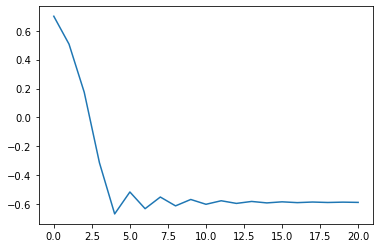

```python
opt23 = optimization(f2, df2, 0.7, 0.1, 20)
x2_print(opt23)
```

初期点-1.4, 学習率0.1, 更新回数20で最適化を実行して、学習過程を描画せよ。  
また、更新後のxの値、目的関数の値を出力せよ。

```
xの値:-1.400,  関数の値:7.426
xの値:1.396,  関数の値:2.232
xの値:1.714,  関数の値:1.046
xの値:2.113,  関数の値:-0.288
xの値:2.316,  関数の値:-0.446
xの値:2.247,  関数の値:-0.456
xの値:2.286,  関数の値:-0.460
xの値:2.266,  関数の値:-0.461
xの値:2.277,  関数の値:-0.461
xの値:2.271,  関数の値:-0.461
xの値:2.274,  関数の値:-0.461
xの値:2.273,  関数の値:-0.461
xの値:2.273,  関数の値:-0.461
xの値:2.273,  関数の値:-0.461
xの値:2.273,  関数の値:-0.461
xの値:2.273,  関数の値:-0.461
xの値:2.273,  関数の値:-0.461
xの値:2.273,  関数の値:-0.461
xの値:2.273,  関数の値:-0.461
xの値:2.273,  関数の値:-0.461
xの値:2.273,  関数の値:-0.461
```

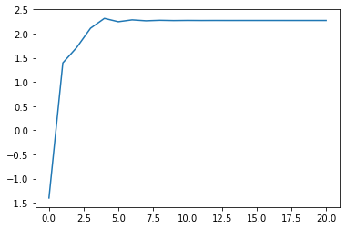

```python
opt24 = optimization(f2, df2, -1.4, 0.1, 20)
x2_print(opt24)
```